# Final Project slides

## Introduction

In this presentation, we will be using a County Dataset (project_177.csv) for the purpose of analyzing the majority of Democrat or Republican votes in the 2016 presidential election by county, which is a two-level categorical y-variable. In the 2016 presidential election, the Democratic Party nominee was Hillary Clinton and the Republican Party nominee was Donald Trump. While the former won the popular vote, the latter won the Electoral College (and therefore the presidency). The purpose of this presentation is to investigate whether socioeconomic trends, patterns, etc. contribute to counties either leaning/voting Democrat or Republican in the 2016 presidential election, and how strong the relationship between these predictor variables and the y-variable (Election Results in 2016) is through various methods.

## Goals for this Project

My goals for this project:

- Learn about which socioeconomic factors are correlated with a county voting Democratic or Republican.
- Apply data visualization techniques and statistical concepts to understanding the relationship between continuous and categorical variables in this dataset.
- Extrapolate based on trends and patterns that are observed when analyzing and maninpulating data so that predictions can be made about future elections, such as in 2020, between the Democratic nominee (Joe Biden) and the Republican nominee (Donald Trump).

## Questions About the Dataset

Some questions I had about the dataset in terms of the y-variable I chose (Election Results in 2016, Democrat or Republican) included:

- Which socioeconomic factors are strongly correlated with whether a county voted Democratic or Republican?
- Is there a statistically significant difference in predictor (x) variables such as unemployment, median household income, high school graduation rate, etc. between counties that voted Democratic and those that voted Republican?
- Does this data help confirm many Americans' assumptions about how socioeconomic differences tend to push groups of people (in this case, counties) toward one political party or the other?

## Downloading, Reading in, and Reviewing the Data

```python
import numpy as np
import pandas as pd
import matplotlib.pyplot as plt
import seaborn as sns
import os
import statsmodels.api as sm
import statsmodels.formula.api as smf
from sklearn import tree
from sklearn.model_selection import train_test_split
```

```python
os.chdir("/Users/keshavramesh/Downloads/Programming Languages/Python/Final Project/")

county_data = pd.read_csv("project_177.csv")
index_col = 0

print(county_data.info())
print(county_data.head())
```

```
<class 'pandas.core.frame.DataFrame'>
RangeIndex: 2715 entries, 0 to 2714
Data columns (total 27 columns):
 #   Column                            Non-Null Count  Dtype
---  ------                            --------------  -----
 0   Row.Label                         2715 non-null   object
 1   Five-digit.FIPS.Code              2715 non-null   int64
 2   State.FIPS.Code                   2715 non-null   int64
 3   County.FIPS.Code                  2715 non-null   int64
 4   State.Abbreviation                2715 non-null   object
 5   CountyName                        2715 non-null   object
 6   Poor.Health                       2715 non-null   float64
 7   Election.Results.2016             2715 non-null   object
 8   Uninsured                         2715 non-null   float64
 9   Primary.Care.Physicians.Per.1000  2715 non-null   float64
```

[output cut: 63 more lines]

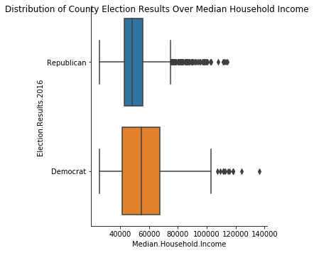

```python
a = sns.catplot(x = "Median.Household.Income", y = "Election.Results.2016", kind = "box", data = county_data, orient = "h")
a.fig.suptitle("Distribution of County Election Results Over Median Household Income")
```

## Two-Sample Test for Equality of Means

Here, we calculate the average value for median household income for Democrats and Republicans, as well as the median value for the median household income for Democrats and Republicans. In both scenarios, we find that Democrats have a higher median value for median household income and average value for median household income than Republicans.

Then, we conduct a two-sample t-test for equality of means and find that the probability that the p-value is greater than t is less than 0.05, so we can reject the null hypothesis and conclude that there is a statistically significant difference between the mean value for median household income for Democrats (which was calculated as 57,005.876682) and the mean value for median household income for Republicans (which was calculated as 50,545.254297).

```python
# Calculate the average Median Household Income for Democrats and Republicans
print(county_data.groupby("Election.Results.2016")["Median.Household.Income"].mean())

# Calculate the median Median Household Income for Democrats and Republicans
print(county_data.groupby("Election.Results.2016")["Median.Household.Income"].median())

# Two-Sample t-test for equality of means
x1 = sm.stats.DescrStatsW(county_data["Median.Household.Income"].loc[county_data["Election.Results.2016"] == "Democrat"])
x2 = sm.stats.DescrStatsW(county_data["Median.Household.Income"].loc[county_data["Election.Results.2016"] == "Republican"])
comp_means = sm.stats.CompareMeans(x1, x2)
comp_means.summary(usevar = "unequal")
```

```
Election.Results.2016
Democrat      57005.876682
Republican    50545.254297
Name: Median.Household.Income, dtype: float64
Election.Results.2016
Democrat      54525.5
Republican    48581.0
Name: Median.Household.Income, dtype: float64
```

Test for equality of means

|  | coef | std err | t | P>\|t\| | [0.025 | 0.975] |
| --- | --- | --- | --- | --- | --- | --- |
| subset #1 | 6460.6224 | 965.904 | 6.689 | 0.000 | 4562.978 | 8358.266 |

## Box Plot and Bar Chart Distributions for Income Inequality

The below box plots and bar charts constructed measure the distribution of county Democrat/Republican election results in 2016 (categorical y-variable) over median household income (continuous x-variable) and separated by income inequality quartiles.

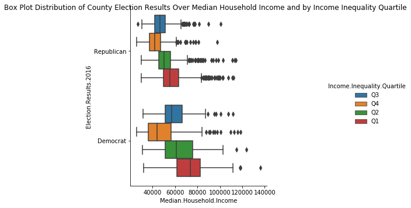

```python
b1 = sns.catplot(x = "Median.Household.Income", y = "Election.Results.2016", hue = "Income.Inequality.Quartile", kind = "box", data = county_data, height = 5, aspect = 1);
b1.fig.suptitle("Box Plot Distribution of County Election Results Over Median Household Income and by Income Inequality Quartile")
```

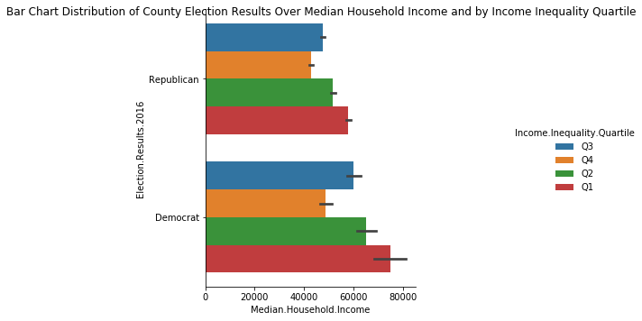

```python
b2 = sns.catplot(x = "Median.Household.Income", y = "Election.Results.2016", hue = "Income.Inequality.Quartile", kind = "bar", data = county_data, height = 5, aspect = 1)
b2.fig.suptitle("Bar Chart Distribution of County Election Results Over Median Household Income and by Income Inequality Quartile")
```

The below box plots and bar charts constructed measure the distribution of county Democrat/Republican election results in 2016 (categorical y-variable) over median household income (continuous x-variable) and separated by food insecurity quintiles.

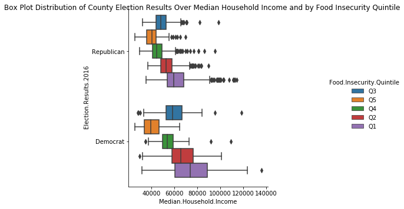

```python
c1 = sns.catplot(x = "Median.Household.Income", y = "Election.Results.2016", hue = "Food.Insecurity.Quintile", kind = "box", data = county_data, height = 5, aspect = 1);
c1.fig.suptitle("Box Plot Distribution of County Election Results Over Median Household Income and by Food Insecurity Quintile")
```

[figure not shown]

```python
c1 = sns.catplot(x = "Median.Household.Income", y = "Election.Results.2016", hue = "Food.Insecurity.Quintile", kind = "bar", data = county_data, height = 5, aspect = 1);
c1.fig.suptitle("Box Plot Distribution of County Election Results Over Median Household Income and by Food Insecurity Quintile")
```

# #

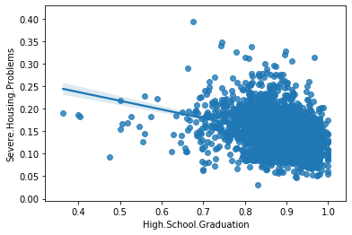

```python
sns.regplot(x = "High.School.Graduation", y = "Severe.Housing.Problems", data = county_data)
```

# #

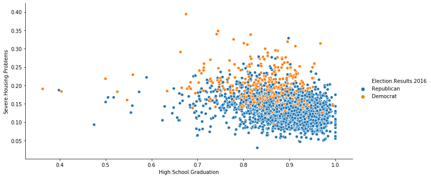

```python
sns.relplot(x = "High.School.Graduation", y = "Severe.Housing.Problems", hue = "Election.Results.2016", data = county_data, height = 5, aspect = 2)
```

# #

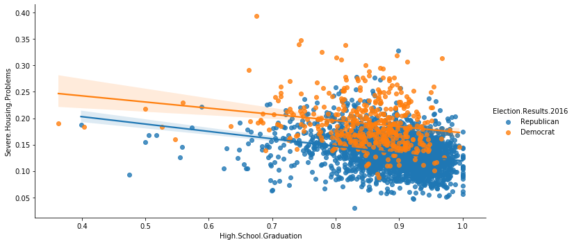

```python
sns.lmplot(x = "High.School.Graduation", y = "Severe.Housing.Problems", hue = "Election.Results.2016", data = county_data, height = 5, aspect = 2)
```

## Fitting a Simple Regression Model

```python
# Fitting simple regression model
olsmod1 = smf.ols(formula = "Q('Severe.Housing.Problems') ~ Q('High.School.Graduation')", data = county_data)
olsres1 = olsmod1.fit()
print(olsres1.summary())
```

```
                                 OLS Regression Results
========================================================================================
Dep. Variable:     Q('Severe.Housing.Problems')   R-squared:                       0.111
Model:                                      OLS   Adj. R-squared:                  0.111
Method:                           Least Squares   F-statistic:                     339.8
Date:                          Wed, 12 Aug 2020   Prob (F-statistic):           1.37e-71
Time:                                  11:05:53   Log-Likelihood:                 4982.6
No. Observations:                          2715   AIC:                            -9961.
Df Residuals:                              2713   BIC:                            -9949.
Df Model:                                     1
Covariance Type:                      nonrobust
===============================================================================================
                                  coef    std err          t      P>|t|      [0.025      0.975]
-----------------------------------------------------------------------------------------------
Intercept                       0.3143      0.009     33.854      0.000       0.296       0.332
Q('High.School.Graduation')    -0.1932      0.010    -18.434      0.000      -0.214      -0.173
==============================================================================
Omnibus:                      409.122   Durbin-Watson:                   1.366
Prob(Omnibus):                  0.000   Jarque-Bera (JB):              917.499
Skew:                           0.873   Prob(JB):                    5.86e-200
Kurtosis:                       5.250   Cond. No.                         25.2
==============================================================================

Warnings:
[1] Standard Errors assume that the covariance matrix of the errors is correctly specified.
```

# Fitting a Parallel Lines Regression Model

```python
# Adding “Election.Results.2016” variable to regression
print(pd.get_dummies(data = county_data["Election.Results.2016"]))

# Fitting parallel lines regression model
olsmod2 = smf.ols(formula = "Q('Severe.Housing.Problems') ~ Q('High.School.Graduation') + Q('Election.Results.2016')", data = county_data)
olsres2 = olsmod2.fit()
print(olsres2.summary())
```

```
      Democrat  Republican
0            0           1
1            0           1
2            0           1
3            0           1
4            0           1
...        ...         ...
2710         0           1
2711         0           1
2712         0           1
2713         0           1
2714         0           1

[2715 rows x 2 columns]
                                 OLS Regression Results
========================================================================================
Dep. Variable:     Q('Severe.Housing.Problems')   R-squared:                       0.305
Model:                                      OLS   Adj. R-squared:                  0.305
Method:                           Least Squares   F-statistic:                     596.2
Date:                          Wed, 12 Aug 2020   Prob (F-statistic):          2.51e-215
Time:                                  11:05:53   Log-Likelihood:                 5317.1
No. Observations:                          2715   AIC:                        -1.063e+04
Df Residuals:                              2712   BIC:                        -1.061e+04
Df Model:                                     2
Covariance Type:                      nonrobust
============================================================================================================
                                               coef    std err          t      P>|t|      [0.025      0.975]
------------------------------------------------------------------------------------------------------------
Intercept                                    0.3046      0.008     37.069      0.000       0.288       0.321
Q('Election.Results.2016')[T.Republican]    -0.0500      0.002    -27.527      0.000      -0.054      -0.046
Q('High.School.Graduation')                 -0.1349      0.010    -14.194      0.000      -0.154      -0.116
==============================================================================
Omnibus:                      259.037   Durbin-Watson:                   1.479
Prob(Omnibus):                  0.000   Jarque-Bera (JB):              477.350
Skew:                           0.645   Prob(JB):                    2.21e-104
Kurtosis:                       4.598   Cond. No.                         30.3
==============================================================================

Warnings:
[1] Standard Errors assume that the covariance matrix of the errors is correctly specified.
```

## Fitting an Interaction Model

```python
# Fitting interaction model
olsmod3 = smf.ols(formula = "Q('Severe.Housing.Problems') ~ Q('High.School.Graduation') + Q('Election.Results.2016') + Q('High.School.Graduation'):Q('Election.Results.2016')", data = county_data)
olsres3 = olsmod3.fit()
print(olsres3.summary())
```

```
                                 OLS Regression Results
========================================================================================
Dep. Variable:     Q('Severe.Housing.Problems')   R-squared:                       0.306
Model:                                      OLS   Adj. R-squared:                  0.305
Method:                           Least Squares   F-statistic:                     397.8
Date:                          Wed, 12 Aug 2020   Prob (F-statistic):          4.33e-214
Time:                                  11:05:54   Log-Likelihood:                 5317.5
No. Observations:                          2715   AIC:                        -1.063e+04
Df Residuals:                              2711   BIC:                        -1.060e+04
Df Model:                                     3
Covariance Type:                      nonrobust
========================================================================================================================================
                                                                           coef    std err          t      P>|t|      [0.025      0.975]
----------------------------------------------------------------------------------------------------------------------------------------
Intercept                                                                0.2890      0.018     16.021      0.000       0.254       0.324
Q('Election.Results.2016')[T.Republican]                                -0.0303      0.020     -1.486      0.137      -0.070       0.010
Q('High.School.Graduation')                                             -0.1166      0.021     -5.498      0.000      -0.158      -0.075
Q('High.School.Graduation'):Q('Election.Results.2016')[T.Republican]    -0.0230      0.024     -0.969      0.333      -0.069       0.024
==============================================================================
Omnibus:                      260.802   Durbin-Watson:                   1.479
Prob(Omnibus):                  0.000   Jarque-Bera (JB):              486.260
Skew:                           0.645   Prob(JB):                    2.57e-106
Kurtosis:                       4.623   Cond. No.                         110.
==============================================================================

Warnings:
[1] Standard Errors assume that the covariance matrix of the errors is correctly specified.
```

## Creating a Decision Tree

The following code involves building a decision tree for Election Results in 2016. Here are the variables to be used as potential predictors:

```
[Row.Label, Five-digit.FIPS.Code, State.FIPS.Code, County.FIPS.Code,
State.Abbreviation, CountyName, Poor.Health, Uninsured,
Primary.Care.Physicians.Per.1000, Mental.health.providers.Per.1000,
Adult.Obesity, Proportion.of.Smokers, High.School.Graduation,
Insufficient.Sleep, Physical.Inactivity, Excessive.Drinking,
Median.Household.Income, Severe.Housing.Problems, Unemployment,
Food.Insecurity.Quintile, Income.Inequality.Quartile, Percent.Rural,
Over.65, Percent.Females, Life.Expectancy, Population]
```

```python
Xcts = county_data[["Five-digit.FIPS.Code", "County.FIPS.Code", "Poor.Health", "Uninsured", "Primary.Care.Physicians.Per.1000",
                    "Mental.health.providers.Per.1000", "Adult.Obesity", "Proportion.of.Smokers", "High.School.Graduation",
                    "Insufficient.Sleep", "Physical.Inactivity", "Excessive.Drinking", "Median.Household.Income",
                   "Severe.Housing.Problems", "Unemployment", "Percent.Rural", "Over.65", "Percent.Females", "Life.Expectancy", "Population"]]

Xcat = pd.get_dummies(county_data[["Row.Label", "State.Abbreviation", "CountyName", "Food.Insecurity.Quintile", "Income.Inequality.Quartile"]], drop_first = True)

X = pd.merge(Xcts, Xcat, left_index = True, right_index = True)
print(X.shape)

y = county_data["Election.Results.2016"]
print(X.head(5))
```

```
(2715, 4445)
   Five-digit.FIPS.Code  County.FIPS.Code  Poor.Health  Uninsured  \
0                  1001                 1       0.1841     0.0850
1                  1003                 3       0.1806     0.1070
2                  1005                 5       0.2577     0.1251
3                  1007                 7       0.2000     0.0968
4                  1009                 9       0.2110     0.1211

   Primary.Care.Physicians.Per.1000  Mental.health.providers.Per.1000  \
0                             0.415                             0.162
1                             0.729                             0.912
2                             0.385                             0.079
3                             0.574                             0.088
4                             0.225                             0.103

```

[output cut: 43 more lines]

```python
X_train, X_test, y_train, y_test = train_test_split(X, y, test_size = 0.5, random_state = 1)
print(X_train.shape)
print(X_test.shape)
```

```
(1357, 4445)
(1358, 4445)
```

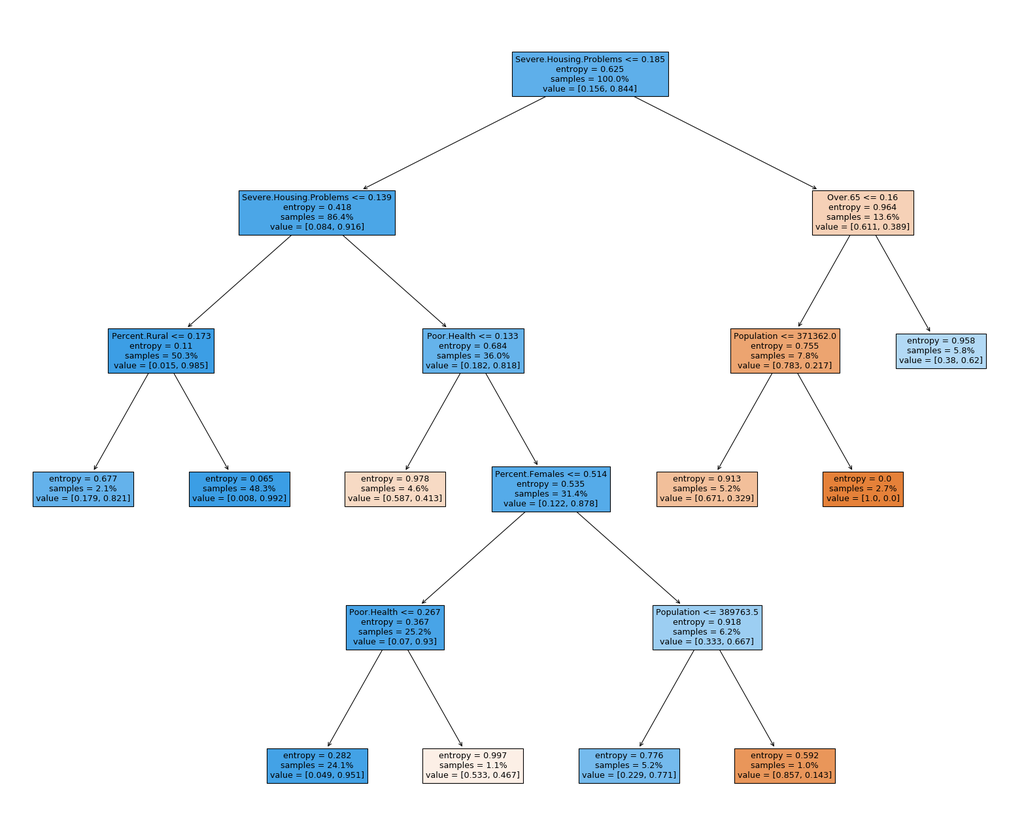

```python
regtree = tree.DecisionTreeClassifier(criterion = "entropy", max_leaf_nodes = 10, random_state = 0)
regtree = regtree.fit(X_train, y_train)

fig = plt.figure(num = None, figsize = (25, 21), dpi = 80, facecolor = "w", edgecolor = "k")
tree.plot_tree(regtree, filled = True, feature_names = X.columns, proportion = True);
```